# Ex01 Visualization

Samuel Hudec

18 septembra 2018

Prvou veľmi podstatnou súčasťou každého štatistického modelovania je obhliadka dát. Ešte pred tým ako začnete rozmýšlať aký model zostaviť, **musíte** dáta najprv videť. Často krát je práve počiatočná obhliatka dát a ich vizualizácia podceňovaný krok. V tomto cvičení sa zameriame na niekoľko základných krokov nutných pred analýzov dát (modelovaním). Postupne počas semestra si osvojíte náročnejšie triky preto cvičenie berte ako *nutný základ*.

```r
library(faraway)
library(car)
library(ggplot2)
```

My budeme väčsinou pracovať s dátami implemenotovanými priamo z knižnice, prvou takouto knižnicou je bude pre vás `faraway`. Okrem datasetov obsahuje aj množstvo funkcií. Spolu s ňou budeme vždy volať aj `car` obsahujúca základné funckie a `ggplot2` (grammar and graphics) na vytváranie profesionálnych obrázkov.

## Study of teenage gambling in Britain

Na tomto datasete si postupne predstavíme **základný** postup *“ohmatania dát”* z knižnice. (neskôr dostanete aj dáta zo Slovenska)

#### Načítanie a oboznámenie sa s problematikou

```r
# načítame dataset z knižnice
data(teengamb)

# ak nacitavate data z kniznice vzdy mate poruke popis
help(teengamb)
# alebo ?teengamb

# v praxi je zaužívané zálohovanie si raw dát
teen = teengamb
# dalej už budeme používať len teen
```

- Čo sa píše v `help` o datasete?
- Aké máme regresory?

*Poznámka: Presne tento druh informácií a ešte viacej sa bežne dozviete od odborníka na danú problematiku.*

#### Bližší náhľad a popisná štatistika

Ak `help` neobsahuje niektoré dôležité informácie viete si ich zistiť pomocou príkazov

```r
# koľko má riadkov (dat) a koľko stlpcov (premenných)
dim(teen)
```

```
## [1] 47  5
```

```r
# počiatocne nakuknutie, zobrazí len prvých 6
head(teen)
```

```
##   sex status income verbal gamble
## 1   1     51   2.00      8    0.0
## 2   1     28   2.50      8    0.0
## 3   1     37   2.00      6    0.0
## 4   1     28   7.00      4    7.3
## 5   1     65   2.00      8   19.6
## 6   1     61   3.47      6    0.1
```

```r
# ak má "veľa" regresorov
names(teen)
```

```
## [1] "sex"    "status" "income" "verbal" "gamble"
```

```r
# popisná štatistika
summary(teengamb)
```

```
##       sex             status          income           verbal
##  Min.   :0.0000   Min.   :18.00   Min.   : 0.600   Min.   : 1.00
##  1st Qu.:0.0000   1st Qu.:28.00   1st Qu.: 2.000   1st Qu.: 6.00
##  Median :0.0000   Median :43.00   Median : 3.250   Median : 7.00
##  Mean   :0.4043   Mean   :45.23   Mean   : 4.642   Mean   : 6.66
##  3rd Qu.:1.0000   3rd Qu.:61.50   3rd Qu.: 6.210   3rd Qu.: 8.00
##  Max.   :1.0000   Max.   :75.00   Max.   :15.000   Max.   :10.00
##      gamble
##  Min.   :  0.0
##  1st Qu.:  1.1
##  Median :  6.0
##  Mean   : 19.3
##  3rd Qu.: 19.4
##  Max.   :156.0
```

- Čo nám prezradila popisná štatistika?
- Obsahujú dáta hrubú chybu (napríklad pri zapisovaní)?
- Čo je teda naša odozva a čo sú prediktori?

#### Oprava a Transformácia

Tento krok sa vykonáva iba ak je potrebný. V tomto prípade nie je potrebné nič opravovať (t.j. prepisovať chybné údaje na základe externej informácie), ale je potrebné pretransformovať premennú pohlavie na faktor.

```r
# zemníme formát na faktor
teen[,1]=as.factor(teen[,1])

# ako to zmenilo popisnu statistiku?
summary(teen)
```

```
##  sex        status          income           verbal          gamble
##  0:28   Min.   :18.00   Min.   : 0.600   Min.   : 1.00   Min.   :  0.0
##  1:19   1st Qu.:28.00   1st Qu.: 2.000   1st Qu.: 6.00   1st Qu.:  1.1
##         Median :43.00   Median : 3.250   Median : 7.00   Median :  6.0
##         Mean   :45.23   Mean   : 4.642   Mean   : 6.66   Mean   : 19.3
##         3rd Qu.:61.50   3rd Qu.: 6.210   3rd Qu.: 8.00   3rd Qu.: 19.4
##         Max.   :75.00   Max.   :15.000   Max.   :10.00   Max.   :156.0
```

Pomocou príkazu `str()` zistíme akého formátu sú regresory v datasete. O niečo všeobecnejší príkaz je `class()`.

#### Prvotná vizualizácia

Prostredie **R** vám ponúka množstvo knižníc zaoberajúcich sa vizualizáciou, my sa zameriame na základné vykreslovanie a popri tom si budeme ukazovať ako vytvárať profesionalnejšie obárzky pomocnou *grammar and graphics* knižníc. Podstatné je čo nám obrázky hovoria a až druhoradý je vzhľad!

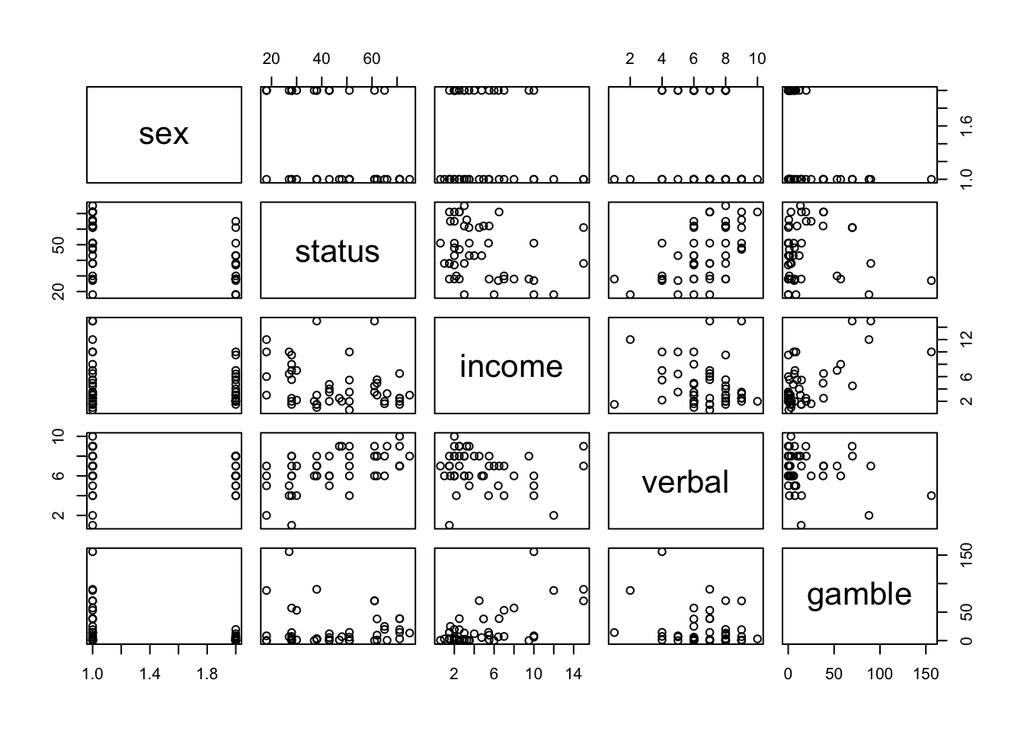

```r
# krížový obázok
pairs(teen)
```

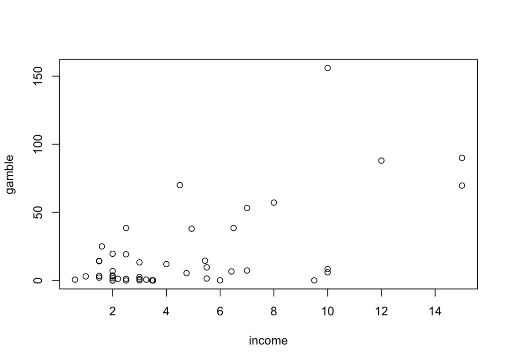

```r
# odozva vs. prediktor
plot(gamble ~ income, data=teen)
```

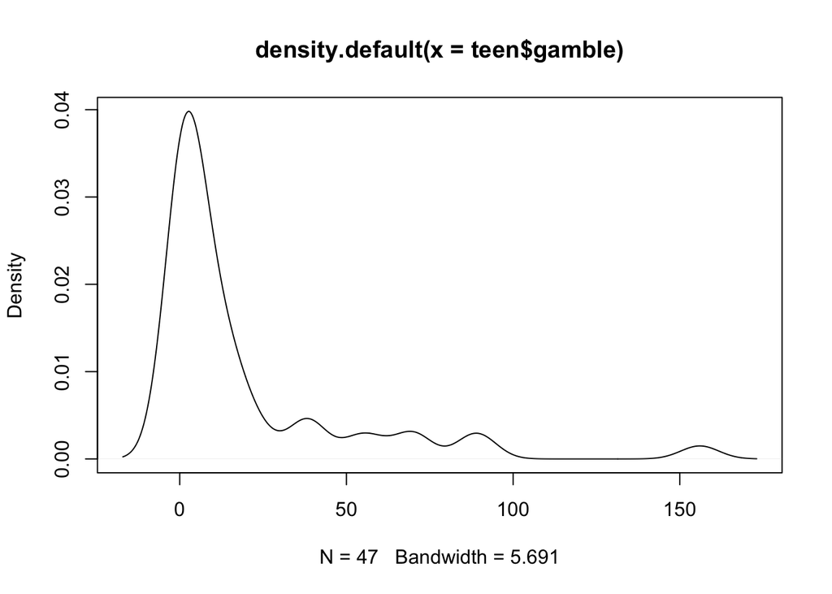

```r
# alebo
# plot(x = teen$income, y = teen$gamble)

# obrázok hustoty
plot(density(teen$gamble))
```

Podobne si vykreslite aj gamble vs. status a verbal. Pokúste sa interpretovať vzťah medzi odozvou a jednotlivými preditkromi.

#### Hlbšia vizualizácia

Užitočným krokom je niektoré premenné vložiť do obrázka tak ako ste to videli v úvode.

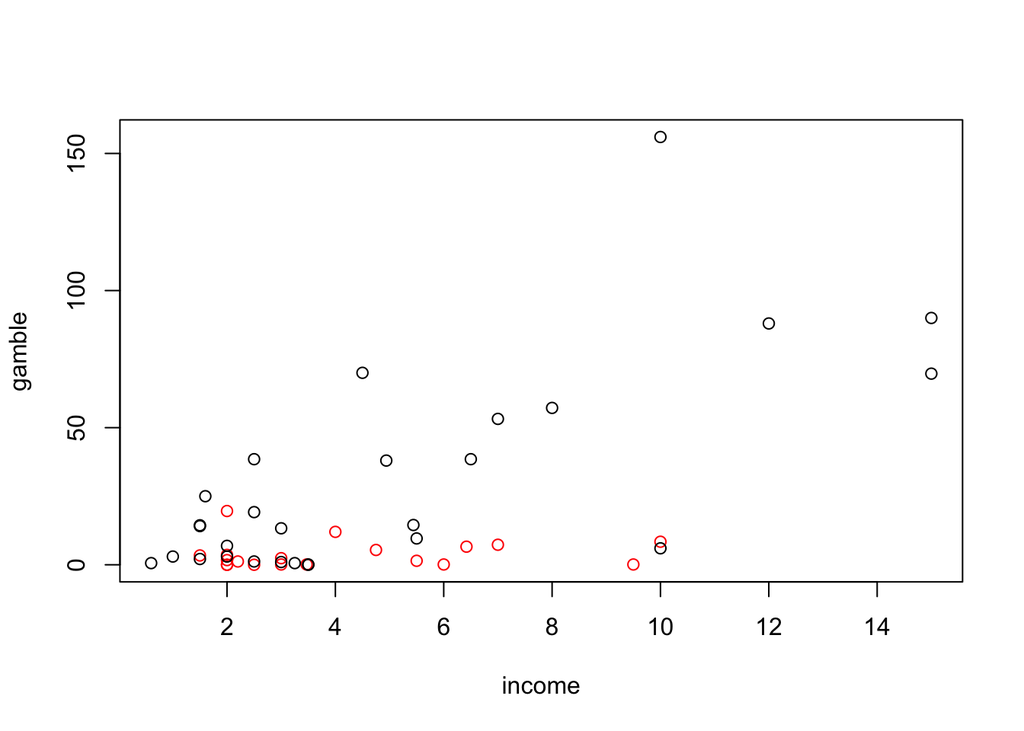

```r
# ofarbením
plot(gamble ~ income, data=teen, col = sex)
```

Teraz nám obárzok prezradil o informáciu navyše. Zopakujte tento krok aj na obrázokch gamble vs. status a verbal.

#### Vizualizácia pomocou ggplot

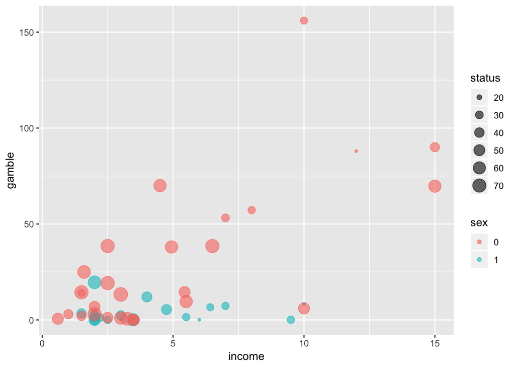

```r
ggplot(data=teen, mapping = aes(x=income, y=gamble, col=sex, size=status)) +
  geom_point(alpha=0.6)
```

Takýto obrázok sa už hodí aj na prezentáciu. Praxou sa naučite vytvárat takéto profesionalnejšie obrázky. Vykreslime si ešte graf hustoty.

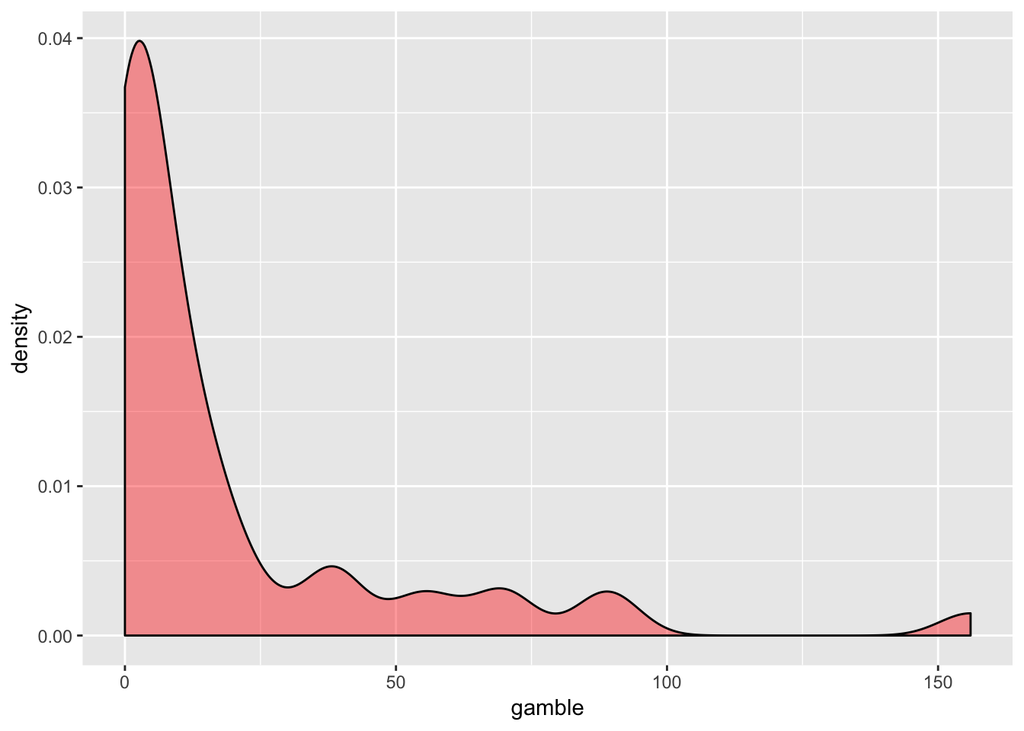

```r
ggplot(data=teen, mapping = aes(x=gamble)) +
  geom_density(fill="red", alpha = 0.4)
```

Znova to vypadá o kus lepšie ako pred tým. Už treba len trenovať, štatistika je ako remeslo, proste to chce prax… Dobrý cheatscheet najtede [tu](https://github.com/rstudio/cheatsheets/blob/master/data-visualization-2.1.pdf).

## Samostatná práca

Analogicky obhliadnite dáta `uswages`, pričom v hrubom dodržujte kroky:

- Načítanie a oboznámenie sa s problematikou
- Bližší náhľad na dáta a popisná štatistika
- Oprava a Transformácia
- Prvotná vizualizácia
- Hlbšia vizualizácia
- Vizualizácia pomocou ggplot (ak bude čas)